# xwMOOC 자연어 처리 - 텍스트

# 1 캐글 스팸 데이터 [^1] [^2]

[SMS Spam Collection Dataset - Collection of SMS messages tagged as spam or legitimate](https://www.kaggle.com/uciml/sms-spam-collection-dataset) 캐글 페이지를 통해 SMS 메시지가 스팸인지 아닌지를 판별하는 기계학습 예측 모형을 개발해보자.

## 1.1 데이터 가져오기

캐글 사이트에서 데이터를 다운로드 받아 압축을 푼다. 그리고 나서 데이터 정제작업을 스팸인지 아닌지를 나타내는 변수를 지정하고 텍스트 메시지 본문에 `text` 변수명을 부여한다. 그리고 나서 SMS 텍스트 길이를 `nchar`, `str_length` 함수로 주요 피처로 산출해낸다.

```r
> library(tidyverse)
> library(stringi)
> spam_df <- read_csv("data/spam.csv", local = locale(encoding = "latin1"))
>
> spam_df <- spam_df %>%
+   rename(label = v1, text = v2) %>%
+   select(label, text) %>%
+   mutate(label = factor(label, levels=c("ham", "spam")))
>
> # https://stackoverflow.com/questions/14363085/invalid-multibyte-string-in-read-csv
> spam_df <- spam_df %>%
+   mutate(text_len = str_length(text))
>
> skimr::skim(spam_df)
```

```
Skim summary statistics
 n obs: 5572
 n variables: 3

-- Variable type:character -----------------------------------------------------------------------------------------------------------------------------------------------------
 variable missing complete    n min max empty n_unique
     text       0     5572 5572   2 910     0     5158

-- Variable type:factor --------------------------------------------------------------------------------------------------------------------------------------------------------
 variable missing complete    n n_unique                 top_counts
    label       0     5572 5572        2 ham: 4825, spa: 747, NA: 0
 ordered
   FALSE

-- Variable type:integer -------------------------------------------------------------------------------------------------------------------------------------------------------
 variable missing complete    n  mean    sd p0 p25 p50 p75 p100     hist
 text_len       0     5572 5572 80.08 59.68  2  35  61 121  910 ▇▃▁▁▁▁▁▁
```

# 2 탐색적 데이터 분석 [^3]

## 2.1 스팸여부 변수

스팸은 747개로 약 13.4%를 차지함이 확인된다. SMS 텍스트 길이에 따른 스팸과 정상 메시지를 겹쳐 보게 되면 텍스트 길이도 중요한 피쳐가 될 수 있음을 확인하게 된다.

```r
> spam_df %>%
+   count(label) %>%
+   mutate(pcnt = scales::percent(n / sum(n)))
```

```
# A tibble: 2 x 3
  label     n pcnt
  <fct> <int> <chr>
1 ham    4825 86.6%
2 spam    747 13.4%
```

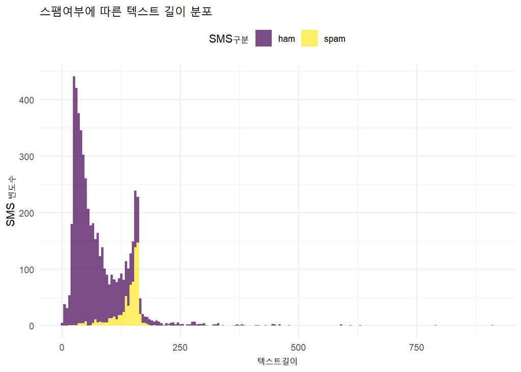

```r
> ggplot(spam_df, aes(x = text_len, fill = label)) +
+   theme_minimal() +
+   geom_histogram(binwidth = 5, alpha=0.7) +
+   labs(y = "SMS 빈도수", x = "텍스트길이", fill = "SMS구분",
+        title = "스팸여부에 따른 텍스트 길이 분포") +
+   scale_fill_viridis_d() +
+   theme(legend.position = "top")
```

# 3 스팸판별 기계학습

## 3.1 훈련/시험 데이터 분할

`caret` 팩키지로 훈련/시험 데이터를 7:3으로 나눠 데이터를 준비한다.

```r
> library(caret)
> index <- createDataPartition(spam_df$label, times = 1, p = 0.7, list = FALSE)
>
> train <- spam_df[index,]
> test  <- spam_df[-index,]
```

## 3.2 텍스트 피처

### 3.2.1 텍스트 데이터 전처리

텍스트 데이터를 기계학습 모형에 사용하려면 토큰화 과정을 거쳐 준비한다. 이를 위해서 먼저 전처리 과정이 필요한데, 이를 위해서 `qdap` 팩키지를 사용해서 텍스트를 전처리한 후에 `quanteda` 팩키지 `token()` 함수의 전처리 기능을 사용해서 토큰화 한다.

그리고 나서 불용어를 제거하고, 어간추출 기법을 사용해서 어간을 뽑아내서 말뭉치를 정제한다.

```r
> library(qdap)
>
> qdap_clean <- function(x) {
+   x <- replace_abbreviation(x)
+   x <- replace_contraction(x)
+   x <- replace_number(x)
+   x <- replace_ordinal(x)
+   x <- replace_symbol(x)
+   x <- tolower(x)
+   return(x)
+ }
>
> train <- train %>%
+   mutate(text = qdap_clean(text))
>
> library(quanteda)
> # SMS 메시지 토큰화
> train_tokens <- tokens(train$text, what = "word",
+                        remove_numbers = TRUE, remove_punct = TRUE,
+                        remove_symbols = TRUE, remove_hyphens = TRUE)
>
> # 불용어 처리
> train_tokens <- tokens_select(train_tokens, stopwords(),
+                               selection = "remove")
>
> # 어간추출(stemming)
> train_tokens <- tokens_wordstem(train_tokens, language = "english")
```

### 3.2.2 피쳐 생성

`quanteda` 팩키지 `dfm()` 함수를 통해 DTM 행렬을 생성하고 나서 이를 행렬로 변환시킨다. ``

```r
> ## 단어주머니 접근법으로 DTM 행렬로 변환
> train_tokens_dfm <- dfm(train_tokens, tolower = FALSE)
> train_tokens_m <- as.matrix(train_tokens_dfm)
```

가장 먼저 스팸과 정상 메시지에 가장 출현빈도가 높은 단어를 추출하여 단어구름(wordcloud)을 제작하여 비교한다.

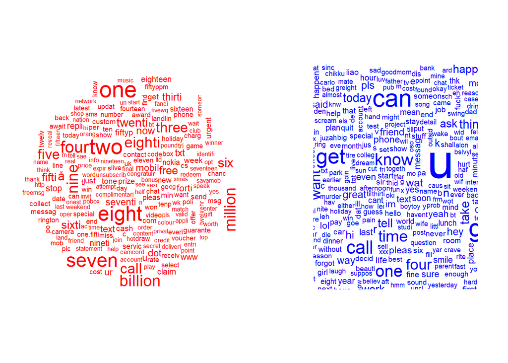

```r
> library(wordcloud)
> train_tokens_df <- train_tokens_m %>%
+   tbl_df %>%
+   bind_cols(label = train$label)
>
> train_tokens_spam_freq <- train_tokens_df %>%
+   filter(label == "spam") %>%
+   select(-label) %>%
+   colSums(.)
>
> train_tokens_ham_freq <- train_tokens_df %>%
+   filter(label == "ham") %>%
+   select(-label) %>%
+   colSums(.)
>
> par(mfrow=c(1,2))
> wordcloud(names(train_tokens_spam_freq), train_tokens_spam_freq, min.freq=10, color = "red")
> wordcloud(names(train_tokens_ham_freq), train_tokens_ham_freq, min.freq=10, color = "blue")
```

## 3.3 나이브 베이즈 적합 [^4]

나이브 베이즈 모형 적합을 하기 전에 단어 빈도수가 적은 것은 뽑아낸다. 그리고 TF-IDF를 계산해서 이를 스팸 예측을 위한 피쳐로 사용한다.

추가 피처(text_len)을 추가하여 `quanteda` 팩키지 `textmodel_nb`에 넣어 모형을 적합시킨다. 그리고 모형성능 예측은 `caret` 팩키지 `confusionMatrix()` 함수를 사용한다.

```r
> # library(klaR)  # caret 나이브베이즈
> train_tokens_dfm <- dfm_trim(train_tokens_dfm, min_termfreq = 5)
> train_tokens_idf <- dfm_tfidf(train_tokens_dfm)
>
> ## 예측모형 행렬
> train_x_df <- cbind(train$text_len, train_tokens_idf)
>
> ## 나이브베이즈 모형 적합
> spam_nb <- textmodel_nb(train_x_df, train$label)
>
> ## 훈련데이터 예측모형 성능
> train_pred <- predict(spam_nb, train_x_df)
> nb_pred_train_tbl <- table(predicted = train_pred, actual=train$label)
>
> confusionMatrix(nb_pred_train_tbl, mode = "everything", positive = "spam")
```

```
Confusion Matrix and Statistics

         actual
predicted  ham spam
     ham  3344   13
     spam   34  510

               Accuracy : 0.988
                 95% CI : (0.984, 0.9911)
    No Information Rate : 0.8659
    P-Value [Acc > NIR] : < 2.2e-16

                  Kappa : 0.949
 Mcnemar's Test P-Value : 0.003531

            Sensitivity : 0.9751
            Specificity : 0.9899
         Pos Pred Value : 0.9375
         Neg Pred Value : 0.9961
              Precision : 0.9375
                 Recall : 0.9751
                     F1 : 0.9560
             Prevalence : 0.1341
         Detection Rate : 0.1307
   Detection Prevalence : 0.1395
      Balanced Accuracy : 0.9825

       'Positive' Class : spam
```

# 4 스팸예측 성능

시험데이터를 통해 스팸성능 예측을 해야 스팸예측 모형의 과적합이 방지되어 일반화가 가능한지 파악할 수 있다. 이를 위해서 나이브베이즈 예측모형에 입력값으로 대입된 데이터 형태를 동일하게 유지해야 한다.

1. `qdap` 팩키지 텍스트 데이터 전처리 수행
2. `quandeta` 팩키지 토큰화 과정
3. 불용어 처리 및 어간 추출 작업
4. 토큰을 단어주머니(Bag-of-Words) DTM 변환
5. **dfm_select()** 함수로 훈련데이터와 동일한 DTM이 되도록 작업
6. TF-IDF 변환
7. 텍스트 길이(`text_len`) 피처 추가

```r
> test <- test %>%
+   mutate(text = qdap_clean(text))
> # SMS 메시지 토큰화
> test_tokens <- tokens(test$text, what = "word",
+                        remove_numbers = TRUE, remove_punct = TRUE,
+                        remove_symbols = TRUE, remove_hyphens = TRUE)
>
> # 불용어 처리
> test_tokens <- tokens_select(test_tokens, stopwords(),
+                               selection = "remove")
>
> # 어간추출(stemming)
> test_tokens <- tokens_wordstem(test_tokens, language = "english")
>
> # 단어주머니 DTM 변환
> test_tokens_dfm <- dfm(test_tokens, tolower = FALSE)
>
> # 단어주머니 DTM 변환
> test_tokens_dfm <- dfm_select(test_tokens_dfm, train_tokens_dfm)
> # TF-IDF 변환
> test_tokens_idf <- dfm_tfidf(test_tokens_dfm)
>
> # 시험데이터 준비
> test_x_df <- cbind(test$text_len, test_tokens_idf)
>
> # 시험데이터 예측
> predicted_class <- predict(spam_nb, test_x_df)
>
> # 성능평가
> nb_pred_test_tbl <- table(predicted = predicted_class, actual=test$label)
> confusionMatrix(nb_pred_test_tbl, mode = "everything", positive = "spam")
```

```
Confusion Matrix and Statistics

         actual
predicted  ham spam
     ham  1428   14
     spam   19  210

               Accuracy : 0.9803
                 95% CI : (0.9724, 0.9864)
    No Information Rate : 0.8659
    P-Value [Acc > NIR] : <2e-16

                  Kappa : 0.9157
 Mcnemar's Test P-Value : 0.4862

            Sensitivity : 0.9375
            Specificity : 0.9869
         Pos Pred Value : 0.9170
         Neg Pred Value : 0.9903
              Precision : 0.9170
                 Recall : 0.9375
                     F1 : 0.9272
             Prevalence : 0.1341
         Detection Rate : 0.1257
   Detection Prevalence : 0.1370
      Balanced Accuracy : 0.9622

       'Positive' Class : spam
```

[^1]: [Jean Dos “SantosHam or Spam? SMS Text Classification Walkthrough”](https://www.kaggle.com/jeandsantos/ham-or-spam-sms-text-classification-walkthrough)
[^2]: [peterjgensler(Nov 23, 2017), “Functions with R and rvest: A Laymen’s Guide”](https://towardsdatascience.com/functions-with-r-and-rvest-a-laymens-guide-acda42325a77)
[^3]: [Anish Singh Walia(2017), “Text Message Classification”](https://datascienceplus.com/text-message-classification/)
[^4]: [quanteda, “NAIVE BAYES CLASSIFIER”](https://tutorials.quanteda.io/machine-learning/nb/)